# Homework 5

Krista Noe

4/4/2021

1. Load data and place into an unmarkedFrameOccu object

```r
y <- read.csv("Bobcat.csv")  # detection / nondetection data
p_covs <- read.csv("p covariates.csv")  # detection covariates
site_covs <- read.csv("psi covariates.csv")  # site coviariates

library(unmarked)
bobcat_mat <- as.matrix(y)

det_covs <- list(
  people = data.frame(p_covs[, c(1:71)])
)

occu_data <- unmarkedFrameOccu(y = bobcat_mat,
                               obsCovs = det_covs,
                               siteCovs = site_covs)
```

2. Fit an occupancy model that assumes conditional detection probability is a function of the number of people photographed at a site, and occupancy probability is a function of disturbance within 5km.

```r
fit <- occu(formula = ~ people ~ Dist_5km, data = occu_data)
summary(fit)
```

```
##
## Call:
## occu(formula = ~people ~ Dist_5km, data = occu_data)
##
## Occupancy (logit-scale):
##             Estimate    SE      z  P(>|z|)
## (Intercept)    -1.05 0.101 -10.39 2.63e-25
## Dist_5km      -23.64 4.773  -4.95 7.28e-07
##
## Detection (logit-scale):
##             Estimate     SE       z P(>|z|)
## (Intercept)  -3.0133 0.0741 -40.646   0.000
## people       -0.0609 0.3779  -0.161   0.872
##
## AIC: 4462.98
## Number of sites: 1951
## optim convergence code: 0
## optim iterations: 39
## Bootstrap iterations: 0
```

3. Interpret the effect of the number of people photographed at each site on conditional detection probability of bobcat. Verity your interpretation in R.

```r
betas <- coef(fit)

p_0 <- plogis(betas[1] + betas[2] + betas[3] + betas[4] * 0)
p_1 <- plogis(betas[1] + betas[2] + betas[3] + betas[4] * 1)

log((p_1 / (1-p_0)) / (p_0 / (1-p_1)))
```

```
##    psi(Int)
## -0.06088908
```

```r
betas[4]
```

```
##   p(people)
## -0.06088908
```

There is a -0.0608 change in the log odds of detecting a bobcat per one person.

4. Re-create the Wald test for the effect of disturbance within 5km. What is the null hypothesis? Do you reject or fail to reject this null hypothesis?

```r
summary(fit)
```

```
##
## Call:
## occu(formula = ~people ~ Dist_5km, data = occu_data)
##
## Occupancy (logit-scale):
##             Estimate    SE      z  P(>|z|)
## (Intercept)    -1.05 0.101 -10.39 2.63e-25
## Dist_5km      -23.64 4.773  -4.95 7.28e-07
##
## Detection (logit-scale):
##             Estimate     SE       z P(>|z|)
## (Intercept)  -3.0133 0.0741 -40.646   0.000
## people       -0.0609 0.3779  -0.161   0.872
##
## AIC: 4462.98
## Number of sites: 1951
## optim convergence code: 0
## optim iterations: 39
## Bootstrap iterations: 0
```

```r
w <- -23.64 / 4.773
w
```

```
## [1] -4.95286
```

```r
2 * pnorm(-1 * abs(w))
```

```
## [1] 7.313065e-07
```

The null hypothesis for this model is the effect on the log odds success of disturbance within 5km is 0. We reject this null hypothesis because our value (7.313065e-07) is less than 0.05.

5. Predict and plot the effect of disturbance within 5km on bobcat occupancy probability. Do this over the range of observed disturbance within 5km.

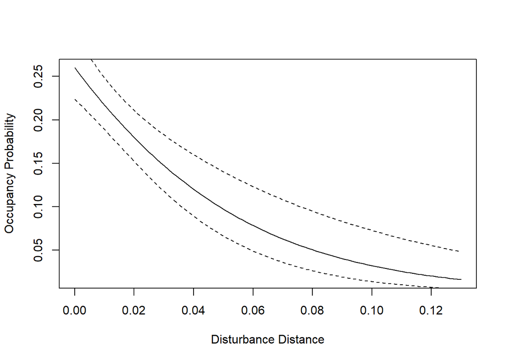

```r
new_psi <- data.frame(people = rep(0, length.out = 100),
                      Dist_5km = seq(from = 0, to = 0.13, length.out = 100))

predict <- predict(object = fit, newdata = new_psi,
            type = 'state')

plot(y = predict$Predicted,
     x = seq(from = min(site_covs$Dist_5km), to = max(site_covs$Dist_5km), length.out = 100),
     xlab = "Disturbance Distance", ylab = "Occupancy Probability", type = "l")
lines(y = predict$lower,
      x = seq(from = min(site_covs$Dist_5km), to = max(site_covs$Dist_5km), length.out = 100), lty = 2)
lines(y = predict$upper,
      x = seq(from = min(site_covs$Dist_5km), to = max(site_covs$Dist_5km), length.out = 100), lty = 2)
```